# KAGGLE PROJECT - HOUSE PREDICTION

Abinav Yadamani

2023-04-16

```r
knitr::opts_chunk$set(echo = TRUE)
library(tidyverse) #Importing the Library tidyverse.
library(DescTools)
```

### Introduction

> The objective of this project is to develop a model which predicts the sales price (target variable) for each house in Ames, Iowa. Every home buyer wants to purchase their ideal home, but it can be challenging to estimate the cost of a home as their could be many factors that needs to considered to arrive at the price. To overcome this, our Linear Regression model will estimate the price of the house using the predictor variables which are most sought to influence the sales price of a house. The benchmark for this model is to have r-squared above 0.85 using as many predictors (variables).

### Import and explore the datasets.

Importing the train and test data files in CSV formats.

```r
train <- read_csv("train.csv") # Get the Train set data.
test <- read_csv("test.csv") # Get the Test set data.
```

> Exploring the dataframe structure for the train set to glance at the variables and their data types.

```r
str(train) # To get the structure of the train dataset.
```

```
## spc_tbl_ [1,460 × 81] (S3: spec_tbl_df/tbl_df/tbl/data.frame)
##  $ Id           : num [1:1460] 1 2 3 4 5 6 7 8 9 10 ...
##  $ MSSubClass   : num [1:1460] 60 20 60 70 60 50 20 60 50 190 ...
##  $ MSZoning     : chr [1:1460] "RL" "RL" "RL" "RL" ...
##  $ LotFrontage  : num [1:1460] 65 80 68 60 84 85 75 NA 51 50 ...
##  $ LotArea      : num [1:1460] 8450 9600 11250 9550 14260 ...
##  $ Street       : chr [1:1460] "Pave" "Pave" "Pave" "Pave" ...
##  $ Alley        : chr [1:1460] NA NA NA NA ...
##  $ LotShape     : chr [1:1460] "Reg" "Reg" "IR1" "IR1" ...
##  $ LandContour  : chr [1:1460] "Lvl" "Lvl" "Lvl" "Lvl" ...
##  $ Utilities    : chr [1:1460] "AllPub" "AllPub" "AllPub" "AllPub" ...
##  $ LotConfig    : chr [1:1460] "Inside" "FR2" "Inside" "Corner" ...
##  $ LandSlope    : chr [1:1460] "Gtl" "Gtl" "Gtl" "Gtl" ...
##  $ Neighborhood : chr [1:1460] "CollgCr" "Veenker" "CollgCr" "Crawfor" ...
##  $ Condition1   : chr [1:1460] "Norm" "Feedr" "Norm" "Norm" ...
##  $ Condition2   : chr [1:1460] "Norm" "Norm" "Norm" "Norm" ...
##  $ BldgType     : chr [1:1460] "1Fam" "1Fam" "1Fam" "1Fam" ...
##  $ HouseStyle   : chr [1:1460] "2Story" "1Story" "2Story" "2Story" ...
##  $ OverallQual  : num [1:1460] 7 6 7 7 8 5 8 7 7 5 ...
##  $ OverallCond  : num [1:1460] 5 8 5 5 5 5 5 6 5 6 ...
##  $ YearBuilt    : num [1:1460] 2003 1976 2001 1915 2000 ...
##  $ YearRemodAdd : num [1:1460] 2003 1976 2002 1970 2000 ...
##  $ RoofStyle    : chr [1:1460] "Gable" "Gable" "Gable" "Gable" ...
##  $ RoofMatl     : chr [1:1460] "CompShg" "CompShg" "CompShg" "CompShg" ...
##  $ Exterior1st  : chr [1:1460] "VinylSd" "MetalSd" "VinylSd" "Wd Sdng" ...
##  $ Exterior2nd  : chr [1:1460] "VinylSd" "MetalSd" "VinylSd" "Wd Shng" ...
##  $ MasVnrType   : chr [1:1460] "BrkFace" "None" "BrkFace" "None" ...
##  $ MasVnrArea   : num [1:1460] 196 0 162 0 350 0 186 240 0 0 ...
##  $ ExterQual    : chr [1:1460] "Gd" "TA" "Gd" "TA" ...
##  $ ExterCond    : chr [1:1460] "TA" "TA" "TA" "TA" ...
##  $ Foundation   : chr [1:1460] "PConc" "CBlock" "PConc" "BrkTil" ...
##  $ BsmtQual     : chr [1:1460] "Gd" "Gd" "Gd" "TA" ...
##  $ BsmtCond     : chr [1:1460] "TA" "TA" "TA" "Gd" ...
##  $ BsmtExposure : chr [1:1460] "No" "Gd" "Mn" "No" ...
##  $ BsmtFinType1 : chr [1:1460] "GLQ" "ALQ" "GLQ" "ALQ" ...
##  $ BsmtFinSF1   : num [1:1460] 706 978 486 216 655 ...
##  $ BsmtFinType2 : chr [1:1460] "Unf" "Unf" "Unf" "Unf" ...
##  $ BsmtFinSF2   : num [1:1460] 0 0 0 0 0 0 0 32 0 0 ...
##  $ BsmtUnfSF    : num [1:1460] 150 284 434 540 490 64 317 216 952 140 ...
##  $ TotalBsmtSF  : num [1:1460] 856 1262 920 756 1145 ...
```

[output cut: 112 more lines]

```
##   ..   EnclosedPorch = col_double(),
##   ..   `3SsnPorch` = col_double(),
##   ..   ScreenPorch = col_double(),
##   ..   PoolArea = col_double(),
##   ..   PoolQC = col_character(),
##   ..   Fence = col_character(),
##   ..   MiscFeature = col_character(),
##   ..   MiscVal = col_double(),
##   ..   MoSold = col_double(),
##   ..   YrSold = col_double(),
##   ..   SaleType = col_character(),
##   ..   SaleCondition = col_character(),
##   ..   SalePrice = col_double()
##   .. )
##  - attr(*, "problems")=<externalptr>
```

> The structure above shows that the train dataset has 80 predictor variables (columns) and SalePrice (target variable) with 1460 rows. The dataset has numeric and character datatypes. Few of the “chr” columns needs to be converted to factor variables before using them in the analysis.

```r
str(test)
```

```
## spc_tbl_ [1,459 × 80] (S3: spec_tbl_df/tbl_df/tbl/data.frame)
##  $ Id           : num [1:1459] 1461 1462 1463 1464 1465 ...
##  $ MSSubClass   : num [1:1459] 20 20 60 60 120 60 20 60 20 20 ...
##  $ MSZoning     : chr [1:1459] "RH" "RL" "RL" "RL" ...
##  $ LotFrontage  : num [1:1459] 80 81 74 78 43 75 NA 63 85 70 ...
##  $ LotArea      : num [1:1459] 11622 14267 13830 9978 5005 ...
##  $ Street       : chr [1:1459] "Pave" "Pave" "Pave" "Pave" ...
##  $ Alley        : chr [1:1459] NA NA NA NA ...
##  $ LotShape     : chr [1:1459] "Reg" "IR1" "IR1" "IR1" ...
##  $ LandContour  : chr [1:1459] "Lvl" "Lvl" "Lvl" "Lvl" ...
##  $ Utilities    : chr [1:1459] "AllPub" "AllPub" "AllPub" "AllPub" ...
##  $ LotConfig    : chr [1:1459] "Inside" "Corner" "Inside" "Inside" ...
##  $ LandSlope    : chr [1:1459] "Gtl" "Gtl" "Gtl" "Gtl" ...
##  $ Neighborhood : chr [1:1459] "NAmes" "NAmes" "Gilbert" "Gilbert" ...
##  $ Condition1   : chr [1:1459] "Feedr" "Norm" "Norm" "Norm" ...
##  $ Condition2   : chr [1:1459] "Norm" "Norm" "Norm" "Norm" ...
##  $ BldgType     : chr [1:1459] "1Fam" "1Fam" "1Fam" "1Fam" ...
##  $ HouseStyle   : chr [1:1459] "1Story" "1Story" "2Story" "2Story" ...
##  $ OverallQual  : num [1:1459] 5 6 5 6 8 6 6 6 7 4 ...
##  $ OverallCond  : num [1:1459] 6 6 5 6 5 5 7 5 5 5 ...
##  $ YearBuilt    : num [1:1459] 1961 1958 1997 1998 1992 ...
##  $ YearRemodAdd : num [1:1459] 1961 1958 1998 1998 1992 ...
##  $ RoofStyle    : chr [1:1459] "Gable" "Hip" "Gable" "Gable" ...
##  $ RoofMatl     : chr [1:1459] "CompShg" "CompShg" "CompShg" "CompShg" ...
##  $ Exterior1st  : chr [1:1459] "VinylSd" "Wd Sdng" "VinylSd" "VinylSd" ...
##  $ Exterior2nd  : chr [1:1459] "VinylSd" "Wd Sdng" "VinylSd" "VinylSd" ...
##  $ MasVnrType   : chr [1:1459] "None" "BrkFace" "None" "BrkFace" ...
##  $ MasVnrArea   : num [1:1459] 0 108 0 20 0 0 0 0 0 0 ...
##  $ ExterQual    : chr [1:1459] "TA" "TA" "TA" "TA" ...
##  $ ExterCond    : chr [1:1459] "TA" "TA" "TA" "TA" ...
##  $ Foundation   : chr [1:1459] "CBlock" "CBlock" "PConc" "PConc" ...
##  $ BsmtQual     : chr [1:1459] "TA" "TA" "Gd" "TA" ...
##  $ BsmtCond     : chr [1:1459] "TA" "TA" "TA" "TA" ...
##  $ BsmtExposure : chr [1:1459] "No" "No" "No" "No" ...
##  $ BsmtFinType1 : chr [1:1459] "Rec" "ALQ" "GLQ" "GLQ" ...
##  $ BsmtFinSF1   : num [1:1459] 468 923 791 602 263 0 935 0 637 804 ...
##  $ BsmtFinType2 : chr [1:1459] "LwQ" "Unf" "Unf" "Unf" ...
##  $ BsmtFinSF2   : num [1:1459] 144 0 0 0 0 0 0 0 0 78 ...
##  $ BsmtUnfSF    : num [1:1459] 270 406 137 324 1017 ...
##  $ TotalBsmtSF  : num [1:1459] 882 1329 928 926 1280 ...
```

[output cut: 110 more lines]

```
##   ..   OpenPorchSF = col_double(),
##   ..   EnclosedPorch = col_double(),
##   ..   `3SsnPorch` = col_double(),
##   ..   ScreenPorch = col_double(),
##   ..   PoolArea = col_double(),
##   ..   PoolQC = col_character(),
##   ..   Fence = col_character(),
##   ..   MiscFeature = col_character(),
##   ..   MiscVal = col_double(),
##   ..   MoSold = col_double(),
##   ..   YrSold = col_double(),
##   ..   SaleType = col_character(),
##   ..   SaleCondition = col_character()
##   .. )
##  - attr(*, "problems")=<externalptr>
```

> The test dataset has 80 predictor variables of numeric and character data types with 1459 rows.Here again, the few of the character columns needs to be converted to factor variables.

### Missing Values

> To obtain the count of the missing values in the train dataset, we have created a function “count_missings” which inturn uses the is.na() function. There are 6965 missing values in the train dataset. Below are all the variables that have at least one NULL or NA values:

```r
count_missings <- function(x) sum(is.na(x))
train %>%
  summarize_all(count_missings)
```

```
## # A tibble: 1 × 81
##      Id MSSubClass MSZoning LotFrontage LotArea Street Alley LotShape
##   <int>      <int>    <int>       <int>   <int>  <int> <int>    <int>
## 1     0          0        0         259       0      0  1369        0
## # ℹ 73 more variables: LandContour <int>, Utilities <int>, LotConfig <int>,
## #   LandSlope <int>, Neighborhood <int>, Condition1 <int>, Condition2 <int>,
## #   BldgType <int>, HouseStyle <int>, OverallQual <int>, OverallCond <int>,
## #   YearBuilt <int>, YearRemodAdd <int>, RoofStyle <int>, RoofMatl <int>,
## #   Exterior1st <int>, Exterior2nd <int>, MasVnrType <int>, MasVnrArea <int>,
## #   ExterQual <int>, ExterCond <int>, Foundation <int>, BsmtQual <int>,
## #   BsmtCond <int>, BsmtExposure <int>, BsmtFinType1 <int>, BsmtFinSF1 <int>, …
```

> Here we have some of the missing or NA values for some of the variables for example Alley has 1369 and PoolQC has 1453 missing values. We will impute the appropriate missing values for the required variables of this model. Based on the data description provided at Kaggle, the missing variables are imputed with either the median (for numeric type)or with the mode (character types).

```r
train <- train %>%
  mutate(LotFrontage = replace_na (LotFrontage,median(LotFrontage, na.rm = TRUE)),
         Alley = replace_na (Alley, replace = "None"),
         MasVnrType = replace_na (MasVnrType, replace = "None"),
         MasVnrArea = replace_na (MasVnrArea, replace = median(MasVnrArea, na.rm = TRUE)),
         BsmtQual = replace_na (BsmtQual, replace = "None"),
         BsmtCond = replace_na (BsmtCond, replace = "None"),
         BsmtExposure = replace_na (BsmtExposure, replace = "None"),
         BsmtFinType1 = replace_na (BsmtFinType1, replace = "None"),
         BsmtFinType2 = replace_na (BsmtFinType2, replace = "None"),
         Electrical = replace_na(Electrical,Mode(Electrical, na.rm = TRUE)),
         FireplaceQu = replace_na (FireplaceQu, replace = "None"),
         GarageType = replace_na (GarageType, replace = "None"),
         GarageYrBlt = replace_na (GarageYrBlt, replace = median(GarageYrBlt, na.rm = TRUE)),
         GarageFinish = replace_na (GarageFinish, replace = "None"),
         GarageQual = replace_na (GarageQual, replace = "None"),
         GarageCond = replace_na (GarageCond, replace = "None"),
         PoolQC = replace_na (PoolQC, replace = "None"),
         Fence = replace_na(Fence, replace = "None"),
         MiscFeature = replace_na(MiscFeature , replace = "None")
         )
```

```r
train %>%
  summarize_all(count_missings)
```

```
## # A tibble: 1 × 81
##      Id MSSubClass MSZoning LotFrontage LotArea Street Alley LotShape
##   <int>      <int>    <int>       <int>   <int>  <int> <int>    <int>
## 1     0          0        0           0       0      0     0        0
## # ℹ 73 more variables: LandContour <int>, Utilities <int>, LotConfig <int>,
## #   LandSlope <int>, Neighborhood <int>, Condition1 <int>, Condition2 <int>,
## #   BldgType <int>, HouseStyle <int>, OverallQual <int>, OverallCond <int>,
## #   YearBuilt <int>, YearRemodAdd <int>, RoofStyle <int>, RoofMatl <int>,
## #   Exterior1st <int>, Exterior2nd <int>, MasVnrType <int>, MasVnrArea <int>,
## #   ExterQual <int>, ExterCond <int>, Foundation <int>, BsmtQual <int>,
## #   BsmtCond <int>, BsmtExposure <int>, BsmtFinType1 <int>, BsmtFinSF1 <int>, …
```

```r
sum(is.na(train))
```

```
## [1] 0
```

> The above table confirms that all the missing values have been imputed and Train is ready for developing the model.

```r
test %>%
  summarize_all(count_missings)
```

```
## # A tibble: 1 × 80
##      Id MSSubClass MSZoning LotFrontage LotArea Street Alley LotShape
##   <int>      <int>    <int>       <int>   <int>  <int> <int>    <int>
## 1     0          0        4         227       0      0  1352        0
## # ℹ 72 more variables: LandContour <int>, Utilities <int>, LotConfig <int>,
## #   LandSlope <int>, Neighborhood <int>, Condition1 <int>, Condition2 <int>,
## #   BldgType <int>, HouseStyle <int>, OverallQual <int>, OverallCond <int>,
## #   YearBuilt <int>, YearRemodAdd <int>, RoofStyle <int>, RoofMatl <int>,
## #   Exterior1st <int>, Exterior2nd <int>, MasVnrType <int>, MasVnrArea <int>,
## #   ExterQual <int>, ExterCond <int>, Foundation <int>, BsmtQual <int>,
## #   BsmtCond <int>, BsmtExposure <int>, BsmtFinType1 <int>, BsmtFinSF1 <int>, …
```

> Now, the same Train cleaning process is followed to clean the Test dataset i.e., missing variables are imputed with either the median (for numeric type)or with the mode (character types).

```r
test <- test %>%
  mutate(MSZoning = replace_na(MSZoning,Mode(MSZoning, na.rm = TRUE)),
         LotFrontage = replace_na (LotFrontage,median(LotFrontage, na.rm = TRUE)),
         Alley = replace_na (Alley, replace = "None"),
         Utilities = replace_na(Utilities,Mode(Utilities, na.rm = TRUE)),
         Exterior1st = replace_na(Exterior1st,Mode(Exterior1st, na.rm = TRUE)),
         Exterior2nd = replace_na(Exterior2nd,Mode(Exterior2nd, na.rm = TRUE)),
         MasVnrType = replace_na (MasVnrType, replace = "None"),
         MasVnrArea = replace_na (MasVnrArea, replace = median(MasVnrArea, na.rm = TRUE)),
         BsmtQual = replace_na (BsmtQual, replace = "None"),
         BsmtCond = replace_na (BsmtCond, replace = "None"),
         BsmtExposure = replace_na (BsmtExposure, replace = "None"),
         BsmtFinType1 = replace_na (BsmtFinType1, replace = "None"),
         BsmtFinSF1 = replace_na (BsmtFinSF1,0),
         BsmtFinType2 = replace_na (BsmtFinType2, replace = "None"),
         BsmtFinSF2 = replace_na (BsmtFinSF2,median(BsmtFinSF2, na.rm = TRUE)),
         BsmtUnfSF = replace_na (BsmtUnfSF,median(BsmtUnfSF, na.rm = TRUE)),
         TotalBsmtSF = replace_na (TotalBsmtSF,median(TotalBsmtSF, na.rm = TRUE)),
         BsmtFullBath = replace_na (BsmtFullBath,median(BsmtFullBath, na.rm = TRUE)),
         BsmtHalfBath = replace_na (BsmtHalfBath,median(BsmtHalfBath, na.rm = TRUE)),
         KitchenQual = replace_na(KitchenQual,Mode(KitchenQual, na.rm = TRUE)),
         Functional = replace_na(Functional,Mode(Functional, na.rm = TRUE)),
         FireplaceQu = replace_na (FireplaceQu, replace = "None"),
         GarageType = replace_na (GarageType, replace = "None"),
         GarageYrBlt = replace_na (GarageYrBlt, replace = median(GarageYrBlt, na.rm = TRUE)),
         GarageFinish = replace_na (GarageFinish, replace = "None"),
         GarageCars = replace_na(GarageCars,Mode(GarageCars, na.rm = TRUE)),
         GarageArea = replace_na (GarageArea,median(GarageArea, na.rm = TRUE)),
         GarageQual = replace_na (GarageQual, replace = "None"),
         GarageCond = replace_na (GarageCond, replace = "None"),
         PoolQC = replace_na (PoolQC, replace = "None"),
         Fence = replace_na(Fence, replace = "None"),
         MiscFeature = replace_na(MiscFeature , replace = "None"),
         SaleType = replace_na(SaleType,Mode(SaleType, na.rm = TRUE))
         )
```

```r
test %>%
  summarize_all(count_missings)
```

```
## # A tibble: 1 × 80
##      Id MSSubClass MSZoning LotFrontage LotArea Street Alley LotShape
##   <int>      <int>    <int>       <int>   <int>  <int> <int>    <int>
## 1     0          0        0           0       0      0     0        0
## # ℹ 72 more variables: LandContour <int>, Utilities <int>, LotConfig <int>,
## #   LandSlope <int>, Neighborhood <int>, Condition1 <int>, Condition2 <int>,
## #   BldgType <int>, HouseStyle <int>, OverallQual <int>, OverallCond <int>,
## #   YearBuilt <int>, YearRemodAdd <int>, RoofStyle <int>, RoofMatl <int>,
## #   Exterior1st <int>, Exterior2nd <int>, MasVnrType <int>, MasVnrArea <int>,
## #   ExterQual <int>, ExterCond <int>, Foundation <int>, BsmtQual <int>,
## #   BsmtCond <int>, BsmtExposure <int>, BsmtFinType1 <int>, BsmtFinSF1 <int>, …
```

```r
sum (is.na(test))
```

```
## [1] 0
```

> Test dataset now has 0 missing values and is ready for the model to be developed.

```r
corr<-cor(train[sapply(train,is.numeric)])
tail(corr)
```

```
##                       Id   MSSubClass   LotFrontage      LotArea OverallQual
## ScreenPorch  0.001330209 -0.026030177  0.0376550774  0.043160378  0.06488636
## PoolArea     0.057043905  0.008282708  0.1808185778  0.077672392  0.06516584
## MiscVal     -0.006242405 -0.007683291 -0.0002553644  0.038067692 -0.03140621
## MoSold       0.021172177 -0.013584643  0.0104506834  0.001204988  0.07081517
## YrSold       0.000711794 -0.021407038  0.0063804333 -0.014261407 -0.02734671
## SalePrice   -0.021916719 -0.084284135  0.3347708531  0.263843354  0.79098160
##              OverallCond    YearBuilt YearRemodAdd   MasVnrArea   BsmtFinSF1
## ScreenPorch  0.054810529 -0.050364435 -0.038740011  0.062247711  0.062020623
## PoolArea    -0.001984942  0.004949728  0.005829372  0.011928394  0.140491286
## MiscVal      0.068776806 -0.034383139 -0.010286249 -0.029512249  0.003571473
## MoSold      -0.003510839  0.012398471  0.021490002 -0.006723204 -0.015726948
## YrSold       0.043949746 -0.013617680  0.035743247 -0.008316623  0.014358922
## SalePrice   -0.077855894  0.522897333  0.507100967  0.472614499  0.386419806
##               BsmtFinSF2   BsmtUnfSF TotalBsmtSF    1stFlrSF    2ndFlrSF
## ScreenPorch  0.088871251 -0.01257927  0.08448899  0.08875807  0.04060645
## PoolArea     0.041709055 -0.03509224  0.12605313  0.13152498  0.08148688
## MiscVal      0.004939781 -0.02383665 -0.01847892 -0.02109572  0.01619687
## MoSold      -0.015210738  0.03488844  0.01319618  0.03137156  0.03516443
## YrSold       0.031705637 -0.04125819 -0.01496865 -0.01360377 -0.02869991
## SalePrice   -0.011378121  0.21447911  0.61358055  0.60585218  0.31933380
##             LowQualFinSF   GrLivArea BsmtFullBath BsmtHalfBath     FullBath
## ScreenPorch  0.026799413  0.10151040   0.02314773  0.032121407 -0.008106093
## PoolArea     0.062157372  0.17020534   0.06761556  0.020024630  0.049603826
## MiscVal     -0.003792871 -0.00241564  -0.02304702 -0.007366525 -0.014289845
## MoSold      -0.022173961  0.05023968  -0.02536089  0.032872705  0.055872129
## YrSold      -0.028920880 -0.03652582   0.06704914 -0.046523882 -0.019668841
## SalePrice   -0.025606130  0.70862448   0.22712223 -0.016844154  0.560663763
##                 HalfBath BedroomAbvGr KitchenAbvGr TotRmsAbvGrd   Fireplaces
## ScreenPorch  0.072425845  0.044299691  -0.05161337   0.05938260  0.184530270
## PoolArea     0.022381498  0.070702584  -0.01452512   0.08375735  0.095073522
## MiscVal      0.001290145  0.007766972   0.06234072   0.02476288  0.001408605
## MoSold      -0.009049888  0.046543860   0.02658891   0.03690708  0.046357102
## YrSold      -0.010268669 -0.036013893   0.03168721  -0.03451635 -0.024095565
## SalePrice    0.284107676  0.168213154  -0.13590737   0.53372316  0.466928837
##               GarageYrBlt  GarageCars  GarageArea   WoodDeckSF OpenPorchSF
## ScreenPorch -0.0761814983  0.05049379  0.05141176 -0.074181351  0.07430394
## PoolArea    -0.0147345140  0.02093353  0.06104727  0.073378207  0.06076211
## MiscVal     -0.0317790318 -0.04308013 -0.02739991 -0.009551228 -0.01858374
## MoSold       0.0049034270  0.04052173  0.02797380  0.021011044  0.07125488
## YrSold      -0.0008290093 -0.03911690 -0.02737794  0.022270451 -0.05761936
## SalePrice    0.4667536524  0.64040920  0.62343144  0.324413445  0.31585623
##             EnclosedPorch     3SsnPorch ScreenPorch    PoolArea      MiscVal
## ScreenPorch  -0.082864245 -0.0314358470  1.00000000  0.05130739  0.031945761
## PoolArea      0.054202562 -0.0079915489  0.05130739  1.00000000  0.029668651
## MiscVal       0.018360600  0.0003539653  0.03194576  0.02966865  1.000000000
## MoSold       -0.028887266  0.0294737952  0.02321699 -0.03373664 -0.006494550
## YrSold       -0.009915937  0.0186449254  0.01069411 -0.05968893  0.004906262
## SalePrice    -0.128577958  0.0445836653  0.11144657  0.09240355 -0.021189580
##                  MoSold       YrSold   SalePrice
## ScreenPorch  0.02321699  0.010694106  0.11144657
## PoolArea    -0.03373664 -0.059688932  0.09240355
## MiscVal     -0.00649455  0.004906262 -0.02118958
## MoSold       1.00000000 -0.145721413  0.04643225
## YrSold      -0.14572141  1.000000000 -0.02892259
## SalePrice    0.04643225 -0.028922585  1.00000000
```

### Choosing the variables

> As per my experience Neighborhood (where the house resides in the city) is the important variable for every house price. It increases from one Neighborhood to other Neighborhood. Neighborhood is chr variable so we can’t use correlation to measure relation between those two variables. But, we can use linear regression model to model for the Neighborhhod and the target variable SalePrice.

```r
model1<- lm(SalePrice~LotFrontage*Neighborhood,data=train)
summary(model1)
```

```
##
## Call:
## lm(formula = SalePrice ~ LotFrontage * Neighborhood, data = train)
##
## Residuals:
##     Min      1Q  Median      3Q     Max
## -185977  -25409   -4134   16962  385255
##
## Coefficients: (1 not defined because of singularities)
##                                   Estimate Std. Error t value Pr(>|t|)
## (Intercept)                      135719.02   66810.75   2.031   0.0424 *
## LotFrontage                        1159.84    1288.29   0.900   0.3681
## NeighborhoodBlueste              -26055.19   51037.52  -0.511   0.6098
## NeighborhoodBrDale              -149229.28  239840.02  -0.622   0.5339
## NeighborhoodBrkSide              -74363.50   71968.94  -1.033   0.3017
## NeighborhoodClearCr              118801.09   83960.71   1.415   0.1573
## NeighborhoodCollgCr               25056.47   69695.85   0.360   0.7193
## NeighborhoodCrawfor               29203.27   73129.08   0.399   0.6897
## NeighborhoodEdwards              -30256.79   67898.57  -0.446   0.6559
## NeighborhoodGilbert               44453.31   69007.83   0.644   0.5196
## NeighborhoodIDOTRR               -39898.30   73625.34  -0.542   0.5880
## NeighborhoodMeadowV              -59817.29   72191.62  -0.829   0.4075
## NeighborhoodMitchel               37223.21   72287.49   0.515   0.6067
## NeighborhoodNAmes                -37790.73   67891.74  -0.557   0.5779
## NeighborhoodNoRidge               18004.62   72959.60   0.247   0.8051
## NeighborhoodNPkVill               20863.04   77324.01   0.270   0.7873
## NeighborhoodNridgHt              -14308.22   69646.81  -0.205   0.8373
## NeighborhoodNWAmes                85864.00   80205.97   1.071   0.2846
## NeighborhoodOldTown              -42306.29   69011.19  -0.613   0.5400
## NeighborhoodSawyer               -30014.86   75664.87  -0.397   0.6917
## NeighborhoodSawyerW             -107568.89   75429.82  -1.426   0.1541
## NeighborhoodSomerst               -4241.19   69002.91  -0.061   0.9510
## NeighborhoodStoneBr               82590.46   74341.14   1.111   0.2668
## NeighborhoodSWISU                -49133.76   89146.93  -0.551   0.5816
## NeighborhoodTimber                32481.22   73533.17   0.442   0.6588
## NeighborhoodVeenker              199748.19   84168.10   2.373   0.0178 *
## LotFrontage:NeighborhoodBlueste         NA         NA      NA       NA
## LotFrontage:NeighborhoodBrDale     4312.81   10744.54   0.401   0.6882
## LotFrontage:NeighborhoodBrkSide     -82.04    1361.49  -0.060   0.9520
## LotFrontage:NeighborhoodClearCr   -1713.96    1447.48  -1.184   0.2366
```

[output cut: 11 more lines]

```
## LotFrontage:NeighborhoodNWAmes    -1584.69    1410.57  -1.123   0.2614
## LotFrontage:NeighborhoodOldTown    -607.34    1315.07  -0.462   0.6443
## LotFrontage:NeighborhoodSawyer     -731.19    1375.90  -0.531   0.5952
## LotFrontage:NeighborhoodSawyerW    1067.50    1376.12   0.776   0.4380
## LotFrontage:NeighborhoodSomerst     283.26    1312.69   0.216   0.8292
## LotFrontage:NeighborhoodStoneBr     281.52    1376.63   0.205   0.8380
## LotFrontage:NeighborhoodSWISU      -222.03    1615.06  -0.137   0.8907
## LotFrontage:NeighborhoodTimber     -207.95    1343.41  -0.155   0.8770
## LotFrontage:NeighborhoodVeenker   -2692.46    1503.68  -1.791   0.0736 .
## ---
## Signif. codes:  0 '***' 0.001 '**' 0.01 '*' 0.05 '.' 0.1 ' ' 1
##
## Residual standard error: 49960 on 1411 degrees of freedom
## Multiple R-squared:  0.6175, Adjusted R-squared:  0.6045
## F-statistic: 47.45 on 48 and 1411 DF,  p-value: < 2.2e-16
```

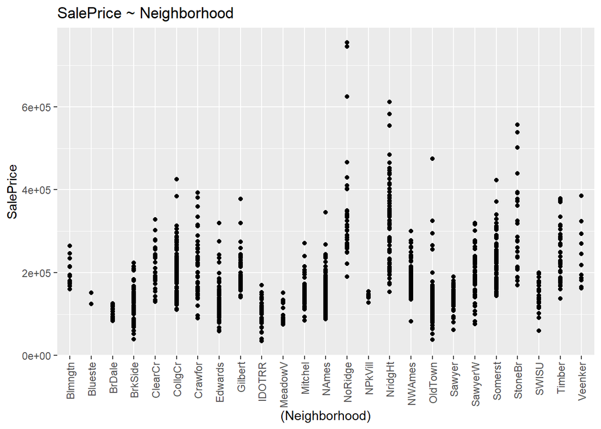

```r
ggplot(train, aes((Neighborhood), SalePrice)) +
  geom_point() +
  labs(title = "SalePrice ~ Neighborhood")+
  theme(axis.text.x = element_text(angle = 90, vjust = 0.5, hjust=1))
```

> Creating the summary table for the neighborhood using mean house price for every neighborhood.

```r
train %>%
  group_by(Neighborhood) %>%
  summarise(mean_average_sale_price = mean(SalePrice)) %>%
  arrange(desc(mean_average_sale_price)) %>%
  head(10)
```

```
## # A tibble: 10 × 2
##    Neighborhood mean_average_sale_price
##    <chr>                          <dbl>
##  1 NoRidge                      335295.
##  2 NridgHt                      316271.
##  3 StoneBr                      310499
##  4 Timber                       242247.
##  5 Veenker                      238773.
##  6 Somerst                      225380.
##  7 ClearCr                      212565.
##  8 Crawfor                      210625.
##  9 CollgCr                      197966.
## 10 Blmngtn                      194871.
```

> NoRidge has his cost for houses, following by NridgHt and StoneBr.